# Part 4

Eric Langowski

```r
joined_mini <- dplyr::tbl(con, 'sales') %>%
  mutate(year = as.double(str_sub(sale_date, 1, 4))) %>%
  left_join(dplyr::tbl(con, 'assessments'),
            by=c('parcel_num'='PARCELNO', 'year')) %>%
  filter(property_c == 401,
         sale_price >= 2000,
         ASSESSEDVALUE >= 1000,
         between(year, 2012, 2019)) %>%
  collect() %>%
  filter(str_detect(str_to_lower(sale_terms), 'valid arm'))

ratios <- cmfproperty::reformat_data(
  joined_mini,
  'sale_price',
  'ASSESSEDVALUE',
  'year'
)
```

```
## [1] "Filtered out non-arm's length transactions"
## [1] "Inflation adjusted to 2019"
```

```r
stats <- cmfproperty::calc_iaao_stats(ratios)
output <- cmfproperty::diagnostic_plots(ratios = ratios, stats = stats, min_reporting_yr =  2012, max_reporting_yr = 2019)

detroit_targ <- st_intersection(wayne_tracts, detroit %>% select(geometry))

detroit_tracts <- wayne_tracts %>% filter(GEOID %in% detroit_targ$GEOID)


targ_geo <- tbl(con, 'attributes') %>%
  filter(property_c == 401) %>%
  select(parcel_num, Longitude, Latitude) %>%
  collect() %>%
  filter(!is.na(Latitude)) %>%
  st_as_sf(coords=c("Longitude", "Latitude"))

st_crs(targ_geo) <- st_crs(detroit_tracts)

parcel_geo <- targ_geo %>% st_join(detroit_tracts, join=st_intersects) %>%
  as.data.frame() %>%
  select(-geometry)
```

# 1 Introduction

The Detroit housing market has experienced historic levels of foreclosures, disinvestment, and demolitions. Over 1 in 4 properties has been foreclosed due to property tax foreclosure since 2011 and many of these foreclosures were due to inaccurate, inflated assessments. These assessments remain problematic even after the City of Detroit undertook its first citywide reassessment in over 60 years which became effective in 2017.

Since the beginning of the coronavirus pandemic, tax foreclosures have been halted and assessments have become more accurate. Detroit’s housing market has begun to recover with some neighborhoods even gentrifying. Yet, the system remains inequitable especially for low-income homeowners of color.

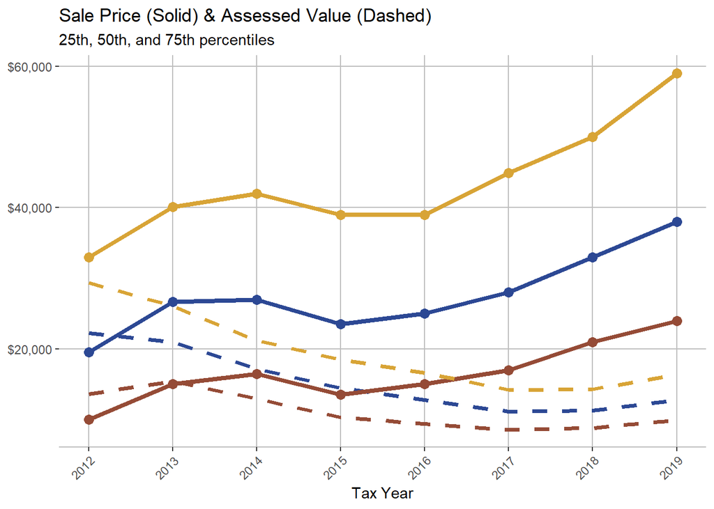

```r
output[[2]]
```

This analysis focuses on single family homes (class 401) which were taxable, sold for more than $2000, and marked as arm’s length by the assessor. Additionally, using the `cmfproperty` package, the IAAO arm’s length standard was applied to the data. This will present a conservative picture of the housing market in Detroit. Note that homes in Detroit as supposed to be assessed at most at 50% of their fair market value.

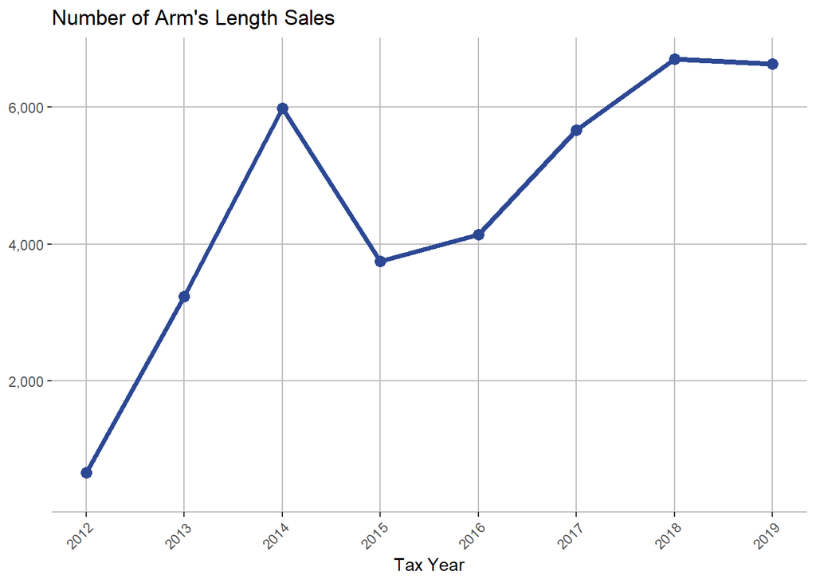

```r
output[[1]]
```

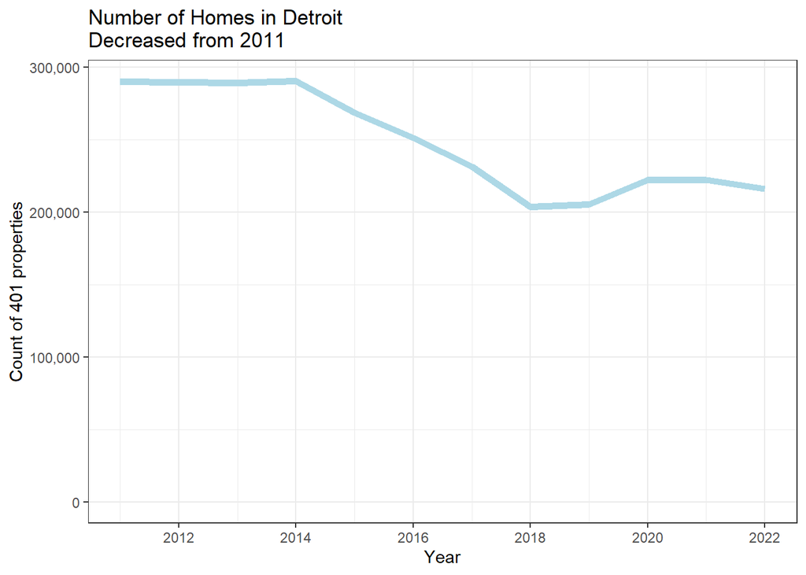

```r
homes_counts <- dplyr::tbl(con, 'assessments') %>% filter(propclass == 401) %>%
  count(year) %>% collect()

ggplot(homes_counts, aes(x=year, y=n)) +
  geom_line(color='light blue', size=2) +
  scale_y_continuous(labels=scales::comma, limit=c(0, NA)) +
  scale_x_continuous(breaks=scales::pretty_breaks()) +
  labs(x='Year', y='Count of 401 properties', title='Number of Homes in Detroit \nDecreased from 2011')
```

# 2 Sales Ratio Analysis

```r
iaao <- cmfproperty::iaao_graphs(stats=stats, ratios=ratios, min_reporting_yr = 2012, max_reporting_yr = 2019, jurisdiction_name = 'Detroit')
```

For 2019, the COD in Detroit was 42.84 which **did not meet** the IAAO standard for uniformity.

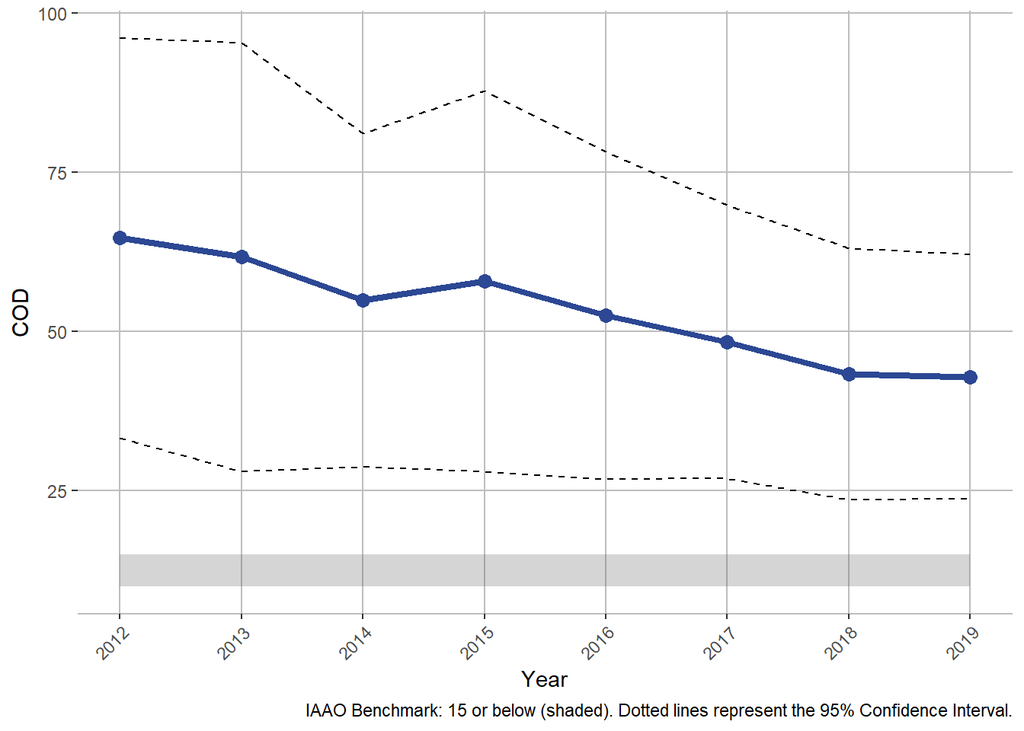

```r
iaao[[2]]
```

In 2019, the PRD in Detroit, was 1.247 which **does not meet** the IAAO standard for vertical equity.

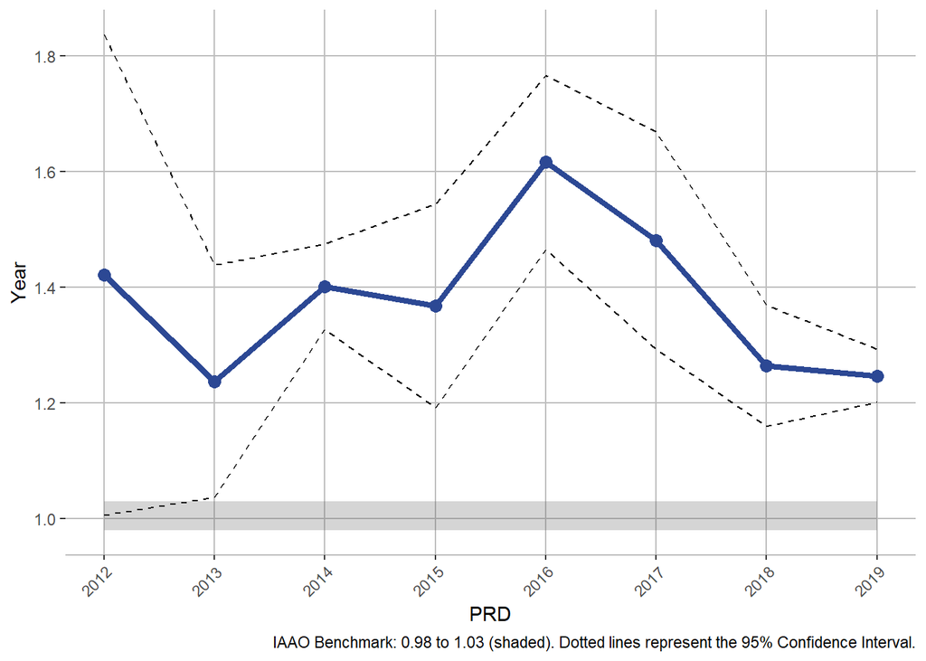

```r
iaao[[4]]
```

In 2019, the PRB in Detroit was -0.354 which indicates that sales ratios decrease by 35.4% when home values double. This **does not meet** the IAAO standard.

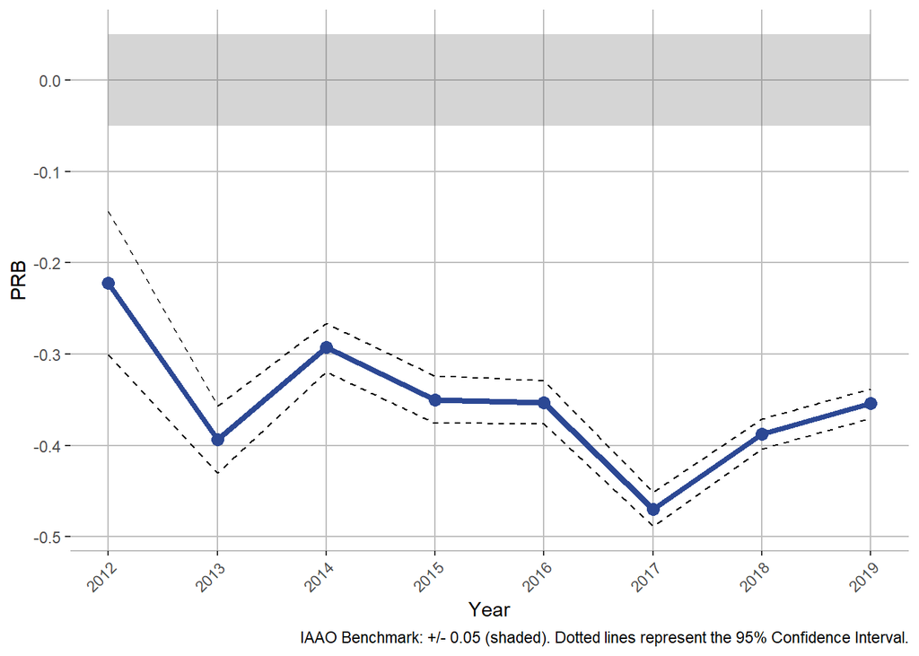

```r
iaao[[6]]
```

```r
bs <- cmfproperty::binned_scatter(ratios = ratios, min_reporting_yr = 2012, max_reporting_yr = 2019, jurisdiction_name = 'Detroit')
```

In 2019, the most expensive homes (the top decile) were assessed at 22.9% of their value and the least expensive homes (the bottom decile) were assessed at 72.6%. In other words, the least expensive homes were assessed at **3.18 times** the rate applied to the most expensive homes. Across our sample from 2012 to 2019, the most expensive homes were assessed at 27.1% of their value and the least expensive homes were assessed at 111.8%, which is **4.12 times** the rate applied to the most expensive homes.

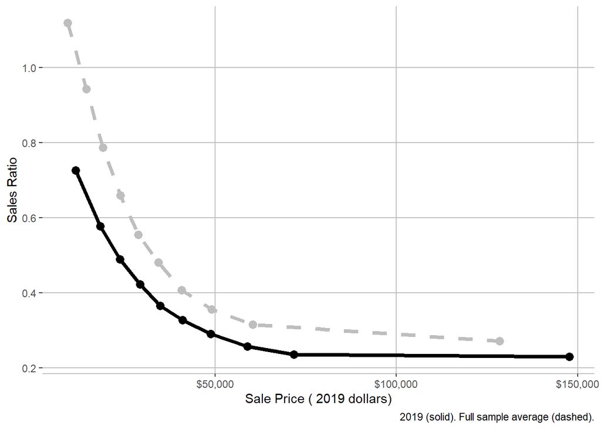

```r
bs[[2]]
```

# 3 Modeling Overassessment

## 3.1 Specifications

```r
targ_sales_16 <-
  tbl(con, 'sales') %>% filter(year(sale_date) == 2016,
                                 sale_price > 2000,
                                 property_c == 401) %>%
      select(-c(grantor, grantee, ecf, property_c)) %>%
      arrange(desc(sale_price)) %>%
      collect() %>%
      filter(str_detect(str_to_lower(sale_terms), 'valid arm')) %>%
      distinct(parcel_num, .keep_all=TRUE)


model_data <- tbl(con, 'assessments') %>%
  filter(year == 2016 | year == 2019,
         propclass == 401,
         ASSESSEDVALUE > 2000) %>%
  collect() %>%
  left_join(
    targ_sales_16,
    by=c('PARCELNO'='parcel_num')
  ) %>%
  left_join(
    tbl(con, 'attributes') %>% select(parcel_num, Neighborhood, total_squa,
                                  heightcat, extcat, has_garage, has_basement,
                                  bathcat, total_floo, year_built, Longitude, Latitude) %>%
      collect(),
    by=c('PARCELNO'='parcel_num')
  ) %>%
  left_join(
    parcel_geo,
    by=c('PARCELNO'='parcel_num')
  )

foreclosures_10_to_15 <- tbl(con, 'foreclosures') %>%
  rename(parcel_num = prop_parcelnum) %>%
  pivot_longer(!c(prop_addr, parcel_num), names_to='Year') %>%
  filter(!is.na(value)) %>%
  left_join(tbl(con, 'attributes') %>% select(parcel_num, Neighborhood)) %>%
  filter(between(as.numeric(Year), 2010, 2015),
         !is.na(Neighborhood)) %>%
  count(Neighborhood) %>% left_join(
    tbl(con, 'attributes') %>% filter(property_c == 401) %>% count(Neighborhood) %>%
  rename(total_prop = n)
  ) %>%
  collect() %>%
  mutate(foreclosures_per_prop = `n` / total_prop) %>%
  select(-n, -total_prop)
share_over_14_to_15 <- ratios %>% filter(between(SALE_YEAR, 2014, 2015)) %>%
  group_by(Neighborhood = ecf) %>%
  summarize(pct_over_50 = length(parcel_num[RATIO > .5]) / n())


avg_sp_per_sqft <- ratios %>% filter(between(SALE_YEAR, 2014, 2018)) %>%
  left_join(tbl(con, 'attributes') %>% select(parcel_num, total_squa) %>% collect()) %>%
  group_by(Neighborhood = ecf) %>%
  summarize(avg_sp_per_sq = mean(SALE_PRICE / total_squa, na.rm=T),
            med_sp_per_sq = median(SALE_PRICE / total_squa, na.rm=T),
            n())
model_data <- model_data %>% mutate(RATIO = ASSESSEDVALUE / sale_price) %>%
  mutate(
  class2 = if_else(RATIO <= .5, 'Under', 'Over'),
  sp_log = log10(sale_price),
  across(contains('cat') | contains('has'), factor)
  ) %>%
  left_join(share_over_14_to_15) %>%
  left_join(foreclosures_10_to_15) %>%
  left_join(avg_sp_per_sqft)
```

### 3.1.1 recipe

```
class_recipe <- recipe(
  class2 ~
    PARCELNO + Neighborhood + ASSESSEDVALUE +
    total_squa + heightcat + extcat + has_garage +
    has_basement + bathcat + total_floo + pct_over_50 +
    foreclosures_per_prop +
    year_built + Latitude + Longitude,
  data = sale_model_data
) %>%
  update_role(PARCELNO, new_role = 'PARCELID') %>%
  step_log(ASSESSEDVALUE) %>%
  step_impute_mean(total_squa, total_floo, year_built, Latitude, Longitude, pct_over_50, foreclosures_per_prop) %>%
  step_dummy(all_nominal_predictors()) %>%
  step_unknown(all_nominal_predictors()) %>%
  prep()
```

## 3.2 Workflow Prep

```r
sale_model_data <- model_data %>% filter(!is.na(RATIO), year == 2016)

folds <- rsample::vfold_cv(sale_model_data, v = 5, strata = class2)

roc_res <- metric_set(roc_auc)

class_model <-
   boost_tree(trees = 250,
              tree_depth = tune(), learn_rate = tune(),
              min_n = tune()) %>%
   set_engine("xgboost") %>%
   set_mode("classification")

class_recipe <- recipe(
  class2 ~
    PARCELNO + Neighborhood +
    ASSESSEDVALUE +
    total_squa + heightcat + extcat + has_garage +
    has_basement + bathcat + total_floo + pct_over_50 +
    foreclosures_per_prop +
    year_built + GEOID,
  data = sale_model_data
) %>%
  step_log(ASSESSEDVALUE) %>%
  step_impute_mean(total_squa, total_floo, year_built, pct_over_50, foreclosures_per_prop) %>%
  step_dummy(all_nominal_predictors()) %>%
  step_unknown(all_nominal_predictors()) %>%
  step_other(threshold = 1e-4) %>%
  prep()
```

## 3.3 Workflow

```r
first_workflow <-
  workflow() %>%
  add_model(class_model) %>%
  add_recipe(class_recipe)

initial_vals <- first_workflow %>%
  tune_grid(
    folds,
    grid = 6,
    metrics = roc_res,
    control = control_grid(verbose=TRUE)
  )
```

[output not shown]

[output not shown]

[output not shown]

[output not shown]

[output not shown]

[output not shown]

[output not shown]

[output not shown]

[output not shown]

[output not shown]

[output not shown]

[output not shown]

[output not shown]

[output not shown]

[output not shown]

[output not shown]

[output not shown]

[output not shown]

[output not shown]

[output not shown]

[output not shown]

[output not shown]

[output not shown]

[output not shown]

[output not shown]

[output not shown]

[output not shown]

[output not shown]

[output not shown]

[output not shown]

[output not shown]

[output not shown]

[output not shown]

[output not shown]

[output not shown]

[output not shown]

[output not shown]

[output not shown]

[output not shown]

[output not shown]

[output not shown]

[output not shown]

[output not shown]

[output not shown]

[output not shown]

[output not shown]

[output not shown]

[output not shown]

[output not shown]

[output not shown]

[output not shown]

[output not shown]

[output not shown]

[output not shown]

[output not shown]

[output not shown]

[output not shown]

[output not shown]

[output not shown]

[output not shown]

[output not shown]

[output not shown]

[output not shown]

[output not shown]

[output not shown]

[output not shown]

[output not shown]

[output not shown]

[output not shown]

[output not shown]

[output not shown]

[output not shown]

[output not shown]

[output not shown]

[output not shown]

[output not shown]

[output not shown]

[output not shown]

[output not shown]

[output not shown]

[output not shown]

[output not shown]

[output not shown]

[output not shown]

[output not shown]

[output not shown]

[output not shown]

[output not shown]

[output not shown]

[output not shown]

[output not shown]

[output not shown]

[output not shown]

[output not shown]

[output not shown]

[output not shown]

[output not shown]

[output not shown]

[output not shown]

[output not shown]

```r
initial_vals %>% collect_metrics()
```

| min_n | tree_depth | learn_rate | .metric | .estimator | mean | n | std_err | .config |
| --- | --- | --- | --- | --- | --- | --- | --- | --- |
| 9 | 15 | 0.002145522 | roc_auc | binary | 0.6485087 | 5 | 0.009146012 | Preprocessor1_Model1 |
| 26 | 7 | 0.020779515 | roc_auc | binary | 0.6583819 | 5 | 0.012118575 | Preprocessor1_Model2 |
| 31 | 11 | 0.008274180 | roc_auc | binary | 0.6571730 | 5 | 0.010120093 | Preprocessor1_Model3 |
| 35 | 10 | 0.112318991 | roc_auc | binary | 0.6437428 | 5 | 0.011555571 | Preprocessor1_Model4 |
| 5 | 4 | 0.002842753 | roc_auc | binary | 0.6410075 | 5 | 0.008086497 | Preprocessor1_Model5 |
| 16 | 3 | 0.201141720 | roc_auc | binary | 0.6421572 | 5 | 0.008828835 | Preprocessor1_Model6 |

```r
ctrl <- control_bayes(verbose = TRUE)

your_search <-
  first_workflow %>%
  tune_bayes(
    resamples = folds,
    metrics = roc_res,
    initial = initial_vals,
    iter = 25,
    control = ctrl
  )
```

[output not shown]

[output not shown]

[output not shown]

[output not shown]

[output not shown]

[output not shown]

[output not shown]

[output not shown]

[output not shown]

[output not shown]

[output not shown]

[output not shown]

[output not shown]

[output not shown]

[output not shown]

[output not shown]

[output not shown]

[output not shown]

[output not shown]

[output not shown]

[output not shown]

[output not shown]

[output not shown]

[output not shown]

[output not shown]

[output not shown]

[output not shown]

[output not shown]

[output not shown]

[output not shown]

[output not shown]

[output not shown]

[output not shown]

[output not shown]

[output not shown]

[output not shown]

[output not shown]

[output not shown]

[output not shown]

[output not shown]

[output not shown]

[output not shown]

[output not shown]

[output not shown]

[output not shown]

[output not shown]

[output not shown]

[output not shown]

[output not shown]

[output not shown]

[output not shown]

[output not shown]

[output not shown]

[output not shown]

[output not shown]

[output not shown]

[output not shown]

[output not shown]

[output not shown]

[output not shown]

[output not shown]

[output not shown]

[output not shown]

[output not shown]

[output not shown]

[output not shown]

[output not shown]

[output not shown]

[output not shown]

[output not shown]

[output not shown]

[output not shown]

[output not shown]

[output not shown]

[output not shown]

[output not shown]

[output not shown]

[output not shown]

[output not shown]

[output not shown]

[output not shown]

[output not shown]

[output not shown]

[output not shown]

[output not shown]

[output not shown]

[output not shown]

[output not shown]

[output not shown]

[output not shown]

[output not shown]

[output not shown]

[output not shown]

[output not shown]

[output not shown]

[output not shown]

[output not shown]

[output not shown]

[output not shown]

[output not shown]

[output not shown]

[output not shown]

[output not shown]

[output not shown]

[output not shown]

[output not shown]

[output not shown]

[output not shown]

[output not shown]

[output not shown]

[output not shown]

[output not shown]

[output not shown]

[output not shown]

[output not shown]

[output not shown]

[output not shown]

[output not shown]

[output not shown]

[output not shown]

[output not shown]

[output not shown]

[output not shown]

[output not shown]

[output not shown]

[output not shown]

[output not shown]

[output not shown]

[output not shown]

[output not shown]

[output not shown]

[output not shown]

[output not shown]

[output not shown]

[output not shown]

[output not shown]

[output not shown]

[output not shown]

[output not shown]

[output not shown]

[output not shown]

[output not shown]

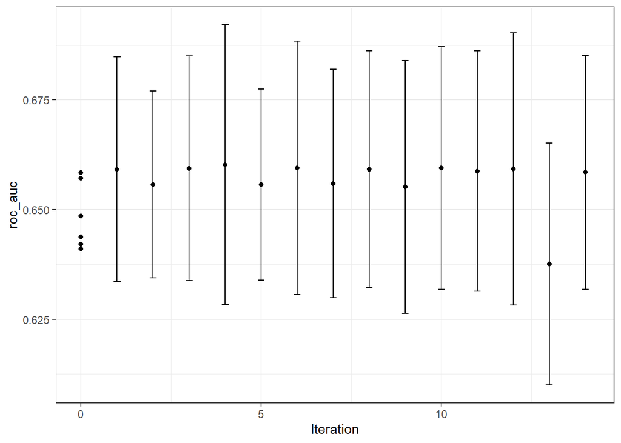

```r
autoplot(your_search, type = "performance")
```

```r
best_results <-
   your_search %>%
   select_best()

model_fit <-
   first_workflow %>%
   finalize_workflow(best_results) %>%
   fit_resamples(folds, control=control_resamples(save_pred=TRUE))
```

```r
our_results <- collect_metrics(model_fit, summarize=TRUE)
our_results %>%
  kableExtra::kable() %>%
  kableExtra::kable_material(c("striped", "hover"))
```

| .metric | .estimator | mean | n | std_err | .config |
| --- | --- | --- | --- | --- | --- |
| accuracy | binary | 0.6283804 | 5 | 0.0065783 | Preprocessor1_Model1 |
| roc_auc | binary | 0.6602585 | 5 | 0.0124185 | Preprocessor1_Model1 |

```r
our_preds <- collect_predictions(model_fit, summarize=TRUE)
our_preds %>%
  count(.pred_class) %>%
  kableExtra::kable() %>%
  kableExtra::kable_material(c("striped", "hover"))
```

| .pred_class | n |
| --- | --- |
| Over | 2777 |
| Under | 1480 |

```r
conf_mat(our_preds, estimate=.pred_class, truth=class2)
```

```
##           Truth
## Prediction Over Under
##      Over  1792   985
##      Under  597   883
```

Our model has pretty mediocre accuracy of 0.628.

## 3.4 Classifier Accuracy Metrics

```r
our_preds <- collect_predictions(model_fit, summarize=TRUE)
multi_metric <- metric_set(recall, specificity, precision, accuracy, f_meas)
multi_metric(our_preds, truth=class2, estimate=.pred_class) %>%
  kableExtra::kable() %>%
  kableExtra::kable_material(c("striped", "hover"))
```

| .metric | .estimator | .estimate |
| --- | --- | --- |
| recall | binary | 0.7501046 |
| specificity | binary | 0.4726981 |
| precision | binary | 0.6453007 |
| accuracy | binary | 0.6283768 |
| f_meas | binary | 0.6937669 |

Some initial views on our model:

```r
sale_model_data %>%
  mutate(pred = our_preds$.pred_class,
         bin = ntile(sale_price, 10)) %>%
  group_by(bin) %>%
  summarize(avg_sp = dollar(mean(sale_price)),
            share_correct = percent(sum(class2 == pred) / n()),
            share_over = percent(sum(class2 == 'Over') / n()))  %>%
  kableExtra::kable() %>%
  kableExtra::kable_material(c("striped", "hover"))
```

| bin | avg_sp | share_correct | share_over |
| --- | --- | --- | --- |
| 1 | $4,774.79 | 72% | 100% |
| 2 | $8,590.98 | 70% | 96% |
| 3 | $12,594.83 | 77% | 89% |
| 4 | $16,311.45 | 78% | 81% |
| 5 | $20,472.82 | 72% | 71% |
| 6 | $25,080.46 | 61% | 53% |
| 7 | $29,715.93 | 57% | 34% |
| 8 | $36,277.41 | 46% | 20% |
| 9 | $46,286.91 | 42% | 14% |
| 10 | $85,590.79 | 53% | 4% |

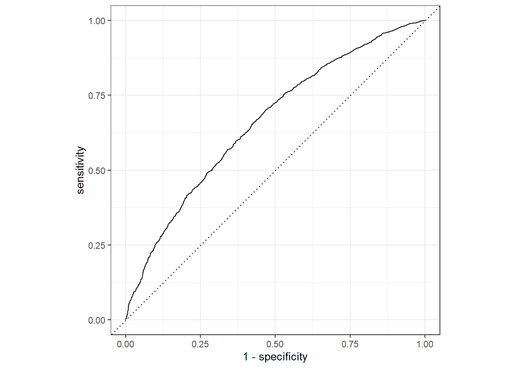

```r
roc_curve(our_preds, class2, .pred_Over) %>%
  autoplot()
```

## 3.5 Predictions

We now fit/train our model on all the sale data and run predictions on all properties.

```r
trained <- first_workflow %>%
   finalize_workflow(best_results) %>% fit(sale_model_data)
```

[output not shown]

```r
all_predictions <- trained %>% augment(model_data %>% filter(year == 2016))

all_predictions %>% count(.pred_class)  %>%
  kableExtra::kable() %>%
  kableExtra::kable_material(c("striped", "hover"))
```

| .pred_class | n |
| --- | --- |
| Over | 133375 |
| Under | 60158 |

Now lets model our predictions across race and make a map.

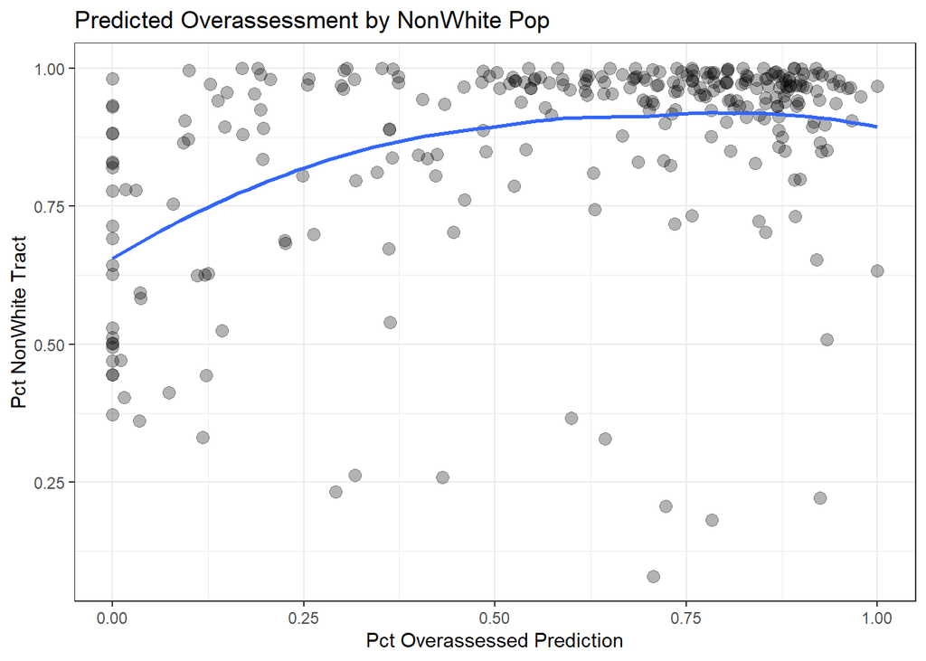

```r
wayne <- get_acs(geography = "tract",
              variables = c(white_alone = "B02001_002",
                            total_pop = "B02001_001",
                            medincome = "B19013_001"),
              state=26, county=163,
              output='wide') %>%
  mutate(pct_nonwhite = (total_popE - white_aloneE) / total_popE) %>%
  select(GEOID, pct_nonwhite, medincomeE)
geoid_over <- all_predictions %>% group_by(GEOID) %>%
  summarize(
    pct_over = sum(.pred_class == 'Over') / n(),
    size = n()
  ) %>%
  filter(!is.na(GEOID)) %>%
  left_join(wayne)
ggplot(geoid_over, aes(x=pct_over, y=pct_nonwhite)) +
  geom_point(alpha=.3, size=3) +
  geom_smooth(se=FALSE) +
  labs(x='Pct Overassessed Prediction', y='Pct NonWhite Tract', title='Predicted Overassessment by NonWhite Pop')
```

```r
library(leaflet)
geo_data <- detroit_tracts %>%
  left_join(geoid_over)
label_str <- str_glue("<strong>Tract %s</strong><br> Pct Over %s<br>")
labels <- sprintf(label_str,
                geo_data$GEOID,
                percent(geo_data$pct_over, .1)) %>%
  lapply(htmltools::HTML)
### make palette
pal1 <-
  colorNumeric(
    palette = "Oranges",
    domain = geo_data$pct_over,
    na.color = "Grey"
  )

m <- leaflet() %>%
  addTiles() %>% addPolygons(
    data = geo_data,
    fillColor = ~ pal1(pct_over),
    weight = 0.5,
    opacity = 0.5,
    color = "white",
    dashArray = 3,
    fillOpacity = 0.7,
    highlight = highlightOptions(
      weight = 5,
      color = "#666",
      dashArray = "",
      fillOpacity = 0.7,
      bringToFront = TRUE
    ),
    label = labels,
    labelOptions = labelOptions(
      style = list("font-weight" = "normal", padding = "3px 8px"),
      textsize = "15px",
      direction = "auto"
    )
  ) %>%
  addLegend(
    pal = pal1,
    values = geo_data$pct_over,
    opacity = 0.7,
    title = NULL,
    position = "bottomright"
  )

m
```

[interactive chart not shown]

# 4 Modeling Assessment

Generating our own assessments (for 2019) is very similar to modeling overassessment. Initially, I will use the same recipe and formula except replacing class with sale price. I will also demonstrate the xgboost (boosted decision tree) package. Boosted decision trees are similar to random forests except each tree is created iteratively in a process of continuous improvement.

```r
time_split <- rsample::initial_time_split(
  ratios %>% select(parcel_num, SALE_PRICE_ADJ, sale_date, ASSESSED_VALUE_ADJ, SALE_YEAR) %>%
    filter(between(SALE_YEAR, 2013, 2018)) %>%
    arrange(sale_date) %>% left_join(
      model_data %>% filter(year == 2019) %>%
        select(-c(RATIO, class2, sp_log, sale_date)), by=c('parcel_num'='PARCELNO')
    ) %>% mutate(sp_log = log10(SALE_PRICE_ADJ),
                 sale_date = ymd(sale_date)),
  .9)

train <- training(time_split)
test <- testing(time_split)

train_resample <- rsample::vfold_cv(train, 3)

linear_reg_spec <-
  linear_reg(penalty = tune(), mixture = tune()) %>%
  set_engine("glmnet")

rf_spec <-
  rand_forest(mtry = tune(),
              min_n = tune(),
              trees = 250) %>%
  set_engine("ranger") %>%
  set_mode("regression")

xgb_spec <-
  boost_tree(
    tree_depth = tune(),
    learn_rate = tune(),
    loss_reduction = tune(),
    min_n = tune(),
    sample_size = tune(),
    trees = tune()
  ) %>%
  set_engine("xgboost") %>%
  set_mode("regression")

reg_recipe <- recipe(sp_log ~  parcel_num + Neighborhood + ASSESSEDVALUE +
    total_squa + heightcat + extcat + has_garage +
    has_basement + bathcat + total_floo + pct_over_50 +
    foreclosures_per_prop +
    year_built + GEOID + sale_date,
                       data=train) %>%
  step_date(sale_date, features = c("dow", "month", "year"), keep_original_cols = FALSE) %>%
  update_role(parcel_num, new_role = 'PARCELID') %>%
  step_log(ASSESSEDVALUE) %>%
  step_impute_mean(ASSESSEDVALUE, total_squa, total_floo,
                   year_built, pct_over_50, foreclosures_per_prop) %>%
  step_unknown(all_nominal_predictors()) %>%
  step_dummy(all_nominal_predictors()) %>%
  prep()

my_set <- workflow_set(
  preproc = list(reg_recp = reg_recipe),
  models = list(linear_reg = linear_reg_spec, random_forest = rf_spec, boosted = xgb_spec)
)

grid_ctrl <-
   control_grid(
      save_pred = FALSE,
      save_workflow = FALSE
   )

grid_results <-
   my_set %>%
   workflow_map(
      seed = 1503,
      resamples = train_resample,
      grid = 6,
      control = grid_ctrl,
      verbose = TRUE
   )
```

[output not shown]

[output not shown]

[output not shown]

[output not shown]

[output not shown]

[output not shown]

[output not shown]

[output not shown]

[output not shown]

[output not shown]

[output not shown]

[output not shown]

[output not shown]

[output not shown]

[output not shown]

[output not shown]

[output not shown]

[output not shown]

[output not shown]

[output not shown]

[output not shown]

[output not shown]

[output not shown]

[output not shown]

[output not shown]

[output not shown]

[output not shown]

[output not shown]

[output not shown]

[output not shown]

[output not shown]

[output not shown]

[output not shown]

[output not shown]

[output not shown]

[output not shown]

[output not shown]

[output not shown]

[output not shown]

[output not shown]

[output not shown]

[output not shown]

[output not shown]

[output not shown]

[output not shown]

[output not shown]

```r
grid_results
```

| wflow_id | info | option | result |
| --- | --- | --- | --- |
| reg_recp_linear_reg |  |  |  |
| reg_recp_random_forest |  |  |  |
| reg_recp_boosted |  |  |  |

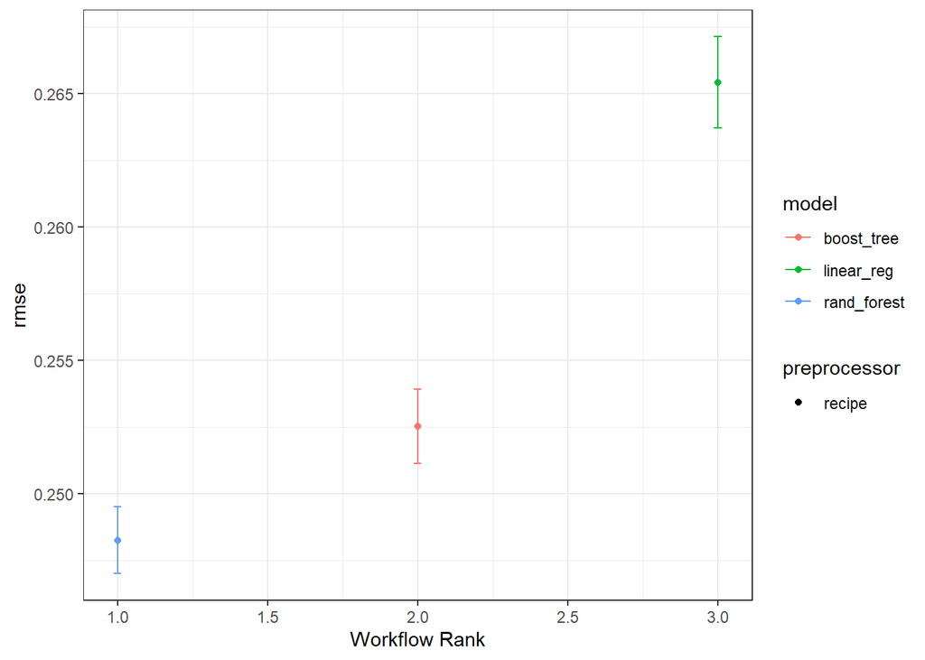

```r
autoplot(
   grid_results,
   rank_metric = "rmse",  # <- how to order models
   metric = "rmse",       # <- which metric to visualize
   select_best = TRUE     # <- one point per workflow
)
```

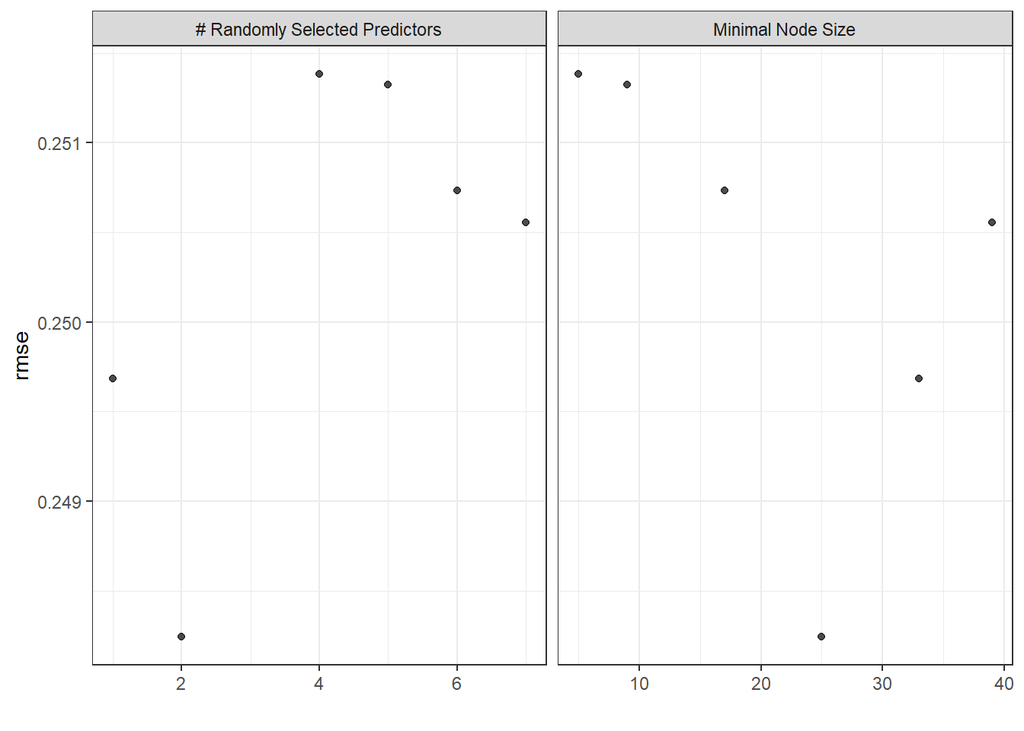

```r
autoplot(
   grid_results,
   id = "reg_recp_random_forest",  # <- how to order models
   metric = "rmse",       # <- which metric to visualize
)
```

```r
best_results <-
   grid_results %>%
   extract_workflow_set_result("reg_recp_random_forest") %>%
   select_best(metric = "rmse")
best_results
```

| mtry | min_n | .config |
| --- | --- | --- |
| 2 | 25 | Preprocessor1_Model4 |

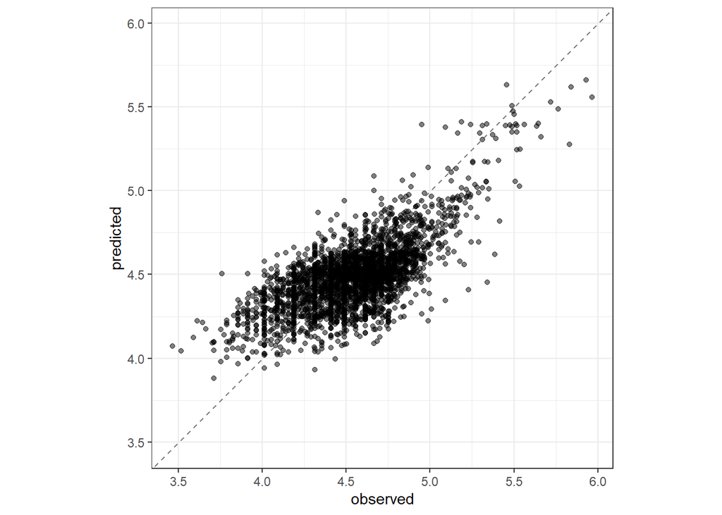

```r
best_results_fit <-
   grid_results %>%
   extract_workflow("reg_recp_random_forest") %>%
   finalize_workflow(best_results) %>%
   last_fit(split = time_split)

best_results_fit %>%
   collect_predictions() %>%
   ggplot(aes(x = sp_log, y = .pred)) +
   geom_abline(color = "gray50", lty = 2) +
   geom_point(alpha = 0.5) +
   coord_obs_pred() +
   labs(x = "observed", y = "predicted")
```

## 4.1 Model Evaluation

```r
model_fit_reg <-
   grid_results %>%
   extract_workflow("reg_recp_random_forest") %>%
   finalize_workflow(best_results) %>%
  fit(train)

our_preds <- model_fit_reg %>% augment(train)

multi_metric <- metric_set(mape, rmse, rsq)
multi_metric(our_preds, truth=sp_log, estimate=.pred) %>%
  kableExtra::kable() %>%
  kableExtra::kable_material(c("striped", "hover"))
```

| .metric | .estimator | .estimate |
| --- | --- | --- |
| mape | standard | 3.4630048 |
| rmse | standard | 0.1893396 |
| rsq | standard | 0.6754234 |

Our model:

```r
our_preds <- model_fit_reg %>% augment(
  test
)

multi_metric(our_preds, truth=sp_log, estimate=.pred) %>%
  kableExtra::kable() %>%
  kableExtra::kable_material(c("striped", "hover"))
```

| .metric | .estimator | .estimate |
| --- | --- | --- |
| mape | standard | 4.0049843 |
| rmse | standard | 0.2222755 |
| rsq | standard | 0.4835306 |

Actual assessments:

```r
multi_metric(our_preds, truth=sp_log, estimate=log10(2*ASSESSED_VALUE_ADJ)) %>%
  kableExtra::kable() %>%
  kableExtra::kable_material(c("striped", "hover"))
```

| .metric | .estimator | .estimate |
| --- | --- | --- |
| mape | standard | 5.0026929 |
| rmse | standard | 0.2868362 |
| rsq | standard | 0.4240782 |

```r
ratios_mini <- cmfproperty::reformat_data(
  our_preds %>% mutate(av_pred = 0.5 * 10^.pred),
  'SALE_PRICE_ADJ',
  'av_pred',
  'SALE_YEAR'
)
```

```
## [1] "Filtered out non-arm's length transactions"
## [1] "Inflation adjusted to 2018"
```

```r
bs <- cmfproperty::binned_scatter(ratios = ratios_mini, min_reporting_yr = 2018, max_reporting_yr = 2018,
                                  jurisdiction_name = 'Detroit')
```

In 2018, the most expensive homes (the top decile) were assessed at 29.5% of their value and the least expensive homes (the bottom decile) were assessed at 77.1%. In other words, the least expensive homes were assessed at **2.62 times** the rate applied to the most expensive homes. Across our sample from 2018 to 2018, the most expensive homes were assessed at 29.5% of their value and the least expensive homes were assessed at 77.1%, which is **2.62 times** the rate applied to the most expensive homes.

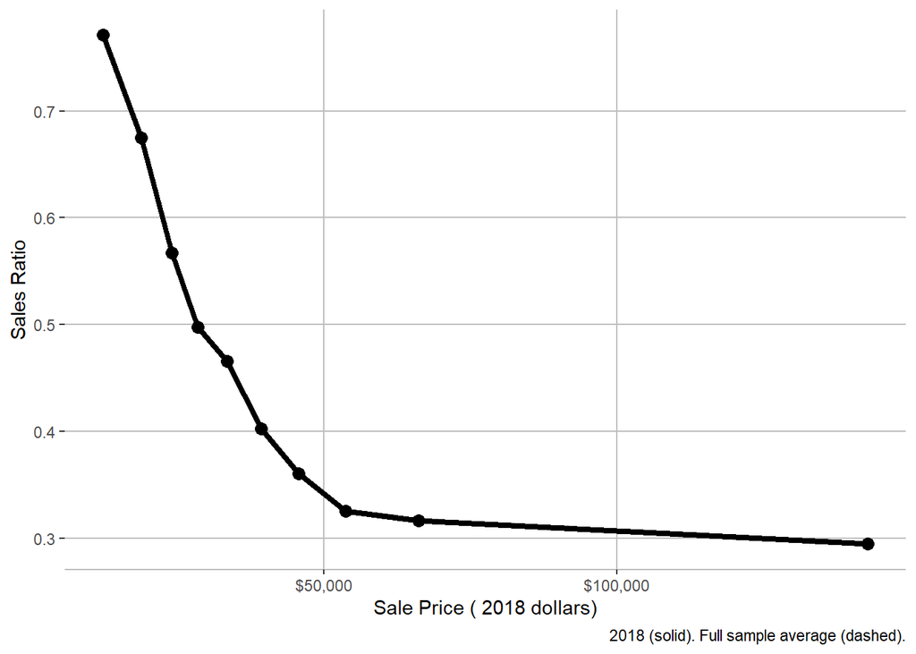

```r
bs[[2]]
```

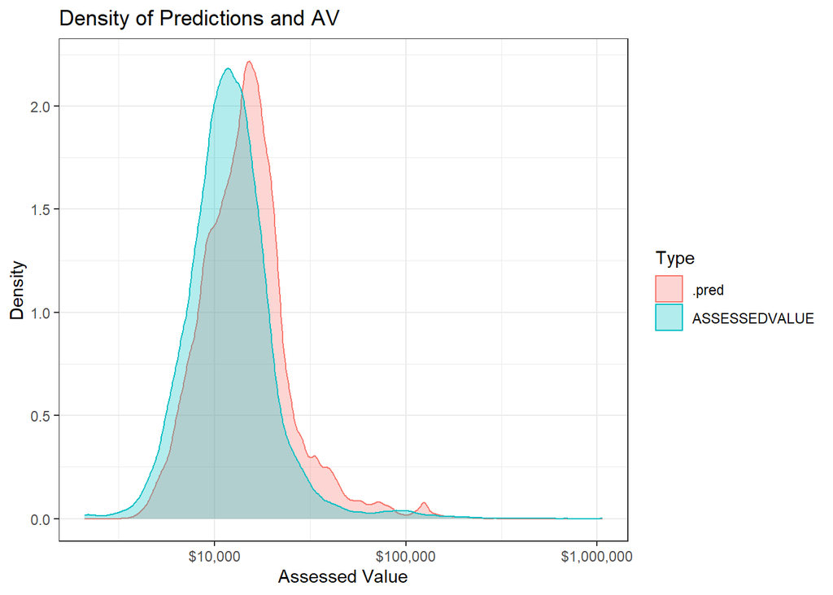

```r
our_preds2 <- model_fit_reg %>% augment(
  model_data %>%
    filter(year == 2019) %>%
    mutate(sale_date = ymd('2019-01-01')) %>%
    rename(parcel_num = PARCELNO)
)

our_preds2 %>%
         select(parcel_num, ASSESSEDVALUE, .pred) %>%
         mutate(.pred = 0.5 * 10^.pred) %>%
         pivot_longer(!parcel_num) %>%
ggplot(aes(x=value, color=name, fill=name)) +
  geom_density(alpha=.3) +
  scale_x_log10(labels=dollar) +
  labs(x = 'Assessed Value', y='Density',
       fill = 'Type', color='Type', title='Density of Predictions and AV')
```

```r
library(DALEXtra)
explain_reg <- explain_tidymodels(
  model_fit_reg,
  data = train %>% select(-contains('ADJ'), -`n()`),
  y = train$sp_log,
  verbose=TRUE
)
```

```
## Preparation of a new explainer is initiated
##   -> model label       :  workflow  (  default  )
##   -> data              :  26527  rows  26  cols
##   -> target variable   :  26527  values
##   -> predict function  :  yhat.workflow  will be used (  default  )
##   -> predicted values  :  No value for predict function target column. (  default  )
##   -> model_info        :  package tidymodels , ver. 0.1.4 , task regression (  default  )
##   -> predicted values  :  numerical, min =  3.709234 , mean =  4.460379 , max =  5.787751
##   -> residual function :  difference between y and yhat (  default  )
##   -> residuals         :  numerical, min =  -0.9898771 , mean =  -4.630158e-05 , max =  2.263042
##   A new explainer has been created!
```

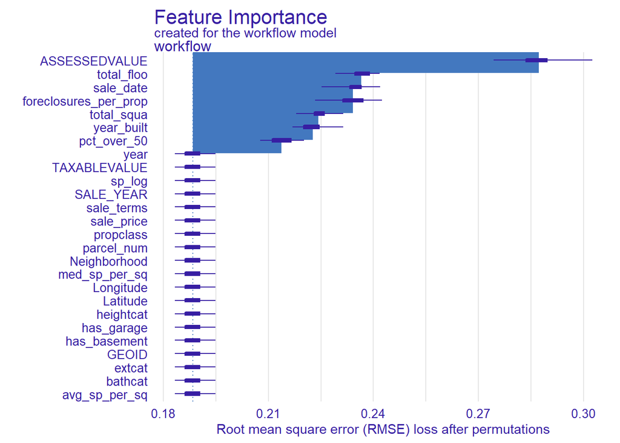

```r
targ <- model_parts(explain_reg, loss_function = loss_root_mean_square)

plot(targ)
```